# L-QLSTM Fleet Emissions Forecaster (Owner: Rikteem Bhowmick)

### Three-Way Comparison: Classical LSTM · Vanilla QLSTM · L-QLSTM (Cao et al.)

## What This Notebook Does

Forecasts daily CO₂e emissions for a fleet of industrial machines and **compares three models** trained on identical data:

| # | Model | Architecture | Key idea |
| --- | --- | --- | --- |
| 1 | **Classical LSTM** | Bidirectional LSTM | Fully classical baseline — fast, no quantum |
| 2 | **Vanilla QLSTM** | 4 VQCs, no Le / Li | LSTM gates → quantum circuits, but **83 % of features wasted** |
| 3 | **L-QLSTM** *(paper)* | Le + 4 VQCs + 4 Li | Shared embedding eliminates qubit waste; per-gate remapping adds expressivity |

## Paper Innovations Applied in Model 3

1. **Shared Le before VQCs** (Eq. 9) — compresses all combined features → N_QUBITS, **0 % qubit waste**
2. **Separate Li after each VQC** (Sec. 3.2) — per-gate linear remap for richer expressivity
3. **SCZ entanglement layer** (Sec. 3.3, Fig. 8) — all-to-all CRZ beats CNOT chain by 34.83 % RMSE

## Forward Pass (Equations 9–15)

```
v_t = [h_{t-1}, x_t]
z_t = Le(v_t)                          # Eq. 9  shared linear embedding  ← L-QLSTM only
f_t = sigmoid( L1( VQC1(z_t) ) )      # Eq. 10 forget gate
i_t = sigmoid( L2( VQC2(z_t) ) )      # Eq. 11 input gate
g_t = tanh   ( L3( VQC3(z_t) ) )      # Eq. 12 cell gate
c_t = f_t * c_{t-1} + i_t * g_t      # Eq. 13 cell state
o_t = sigmoid( L4( VQC4(z_t) ) )      # Eq. 14 output gate
h_t = o_t * tanh(c_t)                 # Eq. 15 hidden state
y_t = Lo(h_t)                          # Eq. 16 output — one Lo head per machine
```

## ▶ How to Run

1. Edit the **Configuration** cell (just below) to change machines, features, or hyperparameters
2. Run all cells top-to-bottom (`Kernel → Restart & Run All`)
3. Results and plots appear in Sections 7–9

```python
# ═══════════════════════════════════════════════════════════════════════════════
# SECTION 1 — CONFIGURATION
# All experiment parameters live here.
# Edit this cell, then run Kernel → Restart & Run All.
# ═══════════════════════════════════════════════════════════════════════════════

# ── Fleet: add / remove machines freely ──────────────────────────────────────
MACHINES = {
    'Excavator_A'  : dict(fuel=12.0, elec=3.5,  heat=18.0, rp=0.002, ra=0.05),
    'Generator_B'  : dict(fuel=8.0,  elec=0.5,  heat=10.0, rp=0.001, ra=0.03),
    'Crane_C'      : dict(fuel=9.5,  elec=5.0,  heat=8.0,  rp=0.003, ra=0.04),
    'Compressor_D' : dict(fuel=5.5,  elec=8.0,  heat=15.0, rp=0.002, ra=0.02),
    'Truck_Fleet'  : dict(fuel=15.0, elec=2.0,  heat=5.0,  rp=0.004, ra=0.06),
}

# ── Emission factors (kg CO₂e per unit) ──────────────────────────────────────
EF = {'fuel': 2.68, 'refrigerant': 2088.0, 'electricity': 0.82, 'heat': 0.27}

# ── Feature streams: add new ones here and generate them in generate_data() ──
FEATURE_COLS = ['fuel_L', 'refrigerant_kg', 'electricity_kWh', 'heat_MJ']

# ── Data ──────────────────────────────────────────────────────────────────────
N_DAYS     = 365
START_DATE = '2024-01-01'

# ── Sequence ──────────────────────────────────────────────────────────────────
LOOKBACK   = 10          # days of history fed as model input

# ── Quantum circuit ───────────────────────────────────────────────────────────
N_QUBITS   = 4           # = HIDDEN_SIZE → 100 % qubit utilisation in L-QLSTM
N_LAYERS   = 2           # SCZ variational depth

# ── Model ─────────────────────────────────────────────────────────────────────
HIDDEN_SIZE = N_QUBITS   # must equal N_QUBITS for the L-QLSTM paper constraint

# ── Training ──────────────────────────────────────────────────────────────────
BATCH_SIZE   = 4
LR           = 0.001     # Adam lr (paper Sec. 4.1)
N_EPOCHS_MAX = 30
N_EPOCHS_MIN = 5
PATIENCE     = 5         # early-stopping patience
TRAIN_FRAC   = 0.64      # 64 / 16 / 20 split (paper Sec. 4.1.1)
VAL_FRAC     = 0.16

# ── Reproducibility ───────────────────────────────────────────────────────────
SEED = 42

# ── Derived — auto-updated when MACHINES / FEATURE_COLS change ───────────────
MACHINE_LIST = list(MACHINES.keys())
N_MACHINES   = len(MACHINES)
INPUT_SIZE   = len(FEATURE_COLS) * N_MACHINES
COMBINED     = INPUT_SIZE + HIDDEN_SIZE
QUBIT_WASTE  = round(100 * (COMBINED - N_QUBITS) / COMBINED, 1)

print("╔══════════════════════════════════════════════════════════╗")
print("║              EXPERIMENT CONFIGURATION                   ║")
print("╠══════════════════════════════════════════════════════════╣")
print(f"║  Machines       : {N_MACHINES} — {', '.join(MACHINE_LIST)}")
print(f"║  Feature streams: {len(FEATURE_COLS)}  →  {FEATURE_COLS}")
print(f"║  Input size     : {len(FEATURE_COLS)} × {N_MACHINES} machines = {INPUT_SIZE} features")
print(f"║  Targets        : {N_MACHINES} (CO₂e kg/day per machine)")
print(f"║  Lookback       : {LOOKBACK} days")
print(f"║  Train/Val/Test : {int(TRAIN_FRAC*100)}/{int(VAL_FRAC*100)}/{int((1-TRAIN_FRAC-VAL_FRAC)*100)} %")
print(f"║  N_QUBITS       : {N_QUBITS}  |  N_LAYERS: {N_LAYERS}  |  Hidden: {HIDDEN_SIZE}")
print(f"║  Batch / LR     : {BATCH_SIZE} / {LR}  |  Max epochs: {N_EPOCHS_MAX}")
print(f"║  Vanilla QLSTM qubit waste : {QUBIT_WASTE} %  ({COMBINED-N_QUBITS}/{COMBINED} features lost)")
print(f"║  L-QLSTM qubit waste       : 0 %  (Le maps all {COMBINED} → {N_QUBITS})")
print("╚══════════════════════════════════════════════════════════╝")
```

```
╔══════════════════════════════════════════════════════════╗
║              EXPERIMENT CONFIGURATION                   ║
╠══════════════════════════════════════════════════════════╣
║  Machines       : 5 — Excavator_A, Generator_B, Crane_C, Compressor_D, Truck_Fleet
║  Feature streams: 4  →  ['fuel_L', 'refrigerant_kg', 'electricity_kWh', 'heat_MJ']
║  Input size     : 4 × 5 machines = 20 features
║  Targets        : 5 (CO₂e kg/day per machine)
║  Lookback       : 10 days
║  Train/Val/Test : 64/16/20 %
║  N_QUBITS       : 4  |  N_LAYERS: 2  |  Hidden: 4
║  Batch / LR     : 4 / 0.001  |  Max epochs: 30
║  Vanilla QLSTM qubit waste : 83.3 %  (20/24 features lost)
║  L-QLSTM qubit waste       : 0 %  (Le maps all 24 → 4)
╚══════════════════════════════════════════════════════════╝
```

## Section 1 — Install and Import

```python
import autoray
import pennylane
print(f"Autoray Location: {autoray.__file__}")
print(f"Autoray Version: {autoray.__version__}")
```

```
Autoray Location: c:\Users\RikteemBhowmick\Projects 2025\L-QSTM\qlstmvenv\Lib\site-packages\autoray\__init__.py
Autoray Version: 0.6.12
```

```python
import numpy as np
import pandas as pd
import matplotlib.pyplot as plt
import matplotlib.dates as mdates
from datetime import timedelta
import warnings; warnings.filterwarnings('ignore')

import torch
import torch.nn as nn
from torch.utils.data import DataLoader, TensorDataset
from copy import deepcopy

import pennylane as qml
from sklearn.preprocessing import MinMaxScaler
from sklearn.metrics import mean_absolute_error, mean_squared_error

np.random.seed(SEED); torch.manual_seed(SEED)

print(f"PennyLane  : {qml.__version__}")
print(f"PyTorch    : {torch.__version__}")
print(f"NumPy      : {np.__version__}")
print(f"Device     : {'CUDA' if torch.cuda.is_available() else 'CPU'}")
print("All libraries imported successfully.")
```

```
PennyLane  : 0.38.0
PyTorch    : 2.3.0+cpu
NumPy      : 1.26.4
Device     : CPU
All libraries imported successfully.
```

## Section 2 — Synthetic Fleet Data

5 machines, 365 days. Patterns: weekday/weekend cycles, seasonal drift, maintenance every 45 days.

```python
def generate_data(machines, n_days=N_DAYS, start=START_DATE):
    """
    Generate synthetic daily fleet emissions data.

    Realistic patterns baked in:
      • Weekday / weekend cycle  — 35 % load on weekends
      • Seasonal drift           — ±12 % sinusoidal variation over the year
      • Maintenance shutdowns    — 15 % load every 45 days per machine
      • Gaussian noise           — measurement uncertainty per energy stream

    To add a new feature stream:
      1. Generate it inside the inner loop (e.g. solar_kWh)
      2. Add it to the records dict
      3. Add its name to FEATURE_COLS in the Config cell
    """
    rng   = np.random.default_rng(SEED)
    dates = pd.date_range(start, periods=n_days, freq='D')
    records = []
    for mname, p in machines.items():
        maint = set(range(0, n_days, 45))
        for i, ts in enumerate(dates):
            wkend  = 0.35 if ts.dayofweek >= 5 else 1.0
            season = 1.0 + 0.12 * np.sin(2 * np.pi * ts.dayofyear / 365)
            mf     = 0.15 if i in maint else 1.0
            load   = rng.uniform(0.65, 1.0) * wkend * season * mf
            fuel   = max(0, p['fuel']*24*load + rng.normal(0, p['fuel']*2))
            elec   = max(0, p['elec']*24*load + rng.normal(0, p['elec']*1.2))
            heat   = max(0, p['heat']*24*load + rng.normal(0, p['heat']*1.0))
            refrig = p['ra'] if rng.random() < p['rp']*24 else 0.0
            co2e   = (fuel*EF['fuel'] + refrig*EF['refrigerant']
                      + elec*EF['electricity'] + heat*EF['heat'])
            records.append(dict(date=ts, machine=mname,
                fuel_L=round(fuel,2), refrigerant_kg=round(refrig,4),
                electricity_kWh=round(elec,2), heat_MJ=round(heat,2),
                co2e_kg=round(co2e,2)))
    return pd.DataFrame(records)

df = generate_data(MACHINES)
fleet_daily = df.groupby('date')['co2e_kg'].sum()

print(f"Dataset  : {df.shape[0]:,} rows  ({N_DAYS} days × {N_MACHINES} machines)")
print(f"\nPer-machine CO₂e summary (kg/day):")
summary = df.groupby('machine')['co2e_kg'].agg(['mean','min','max','std']).round(1)
summary.columns = ['Mean', 'Min', 'Max', 'Std']
print(summary.to_string())
print(f"\nFleet total     : {df['co2e_kg'].sum()/1000:.1f} t CO₂e over {N_DAYS} days")
print(f"Fleet daily avg : {fleet_daily.mean():.1f} kg/day  "
      f"(range {fleet_daily.min():.0f} – {fleet_daily.max():.0f})")
df.head(3)
```

```
Dataset  : 1,825 rows  (365 days × 5 machines)

Per-machine CO₂e summary (kg/day):
               Mean   Min     Max    Std
machine
Compressor_D  403.1  35.0   716.8  168.4
Crane_C       498.7   7.5   886.1  217.5
Excavator_A   631.8   3.0  1168.3  275.5
Generator_B   390.0   4.2   714.2  167.3
Truck_Fleet   702.6   9.0  1272.2  306.2

Fleet total     : 958.6 t CO₂e over 365 days
Fleet daily avg : 2626.2 kg/day  (range 241 – 4226)
```

|  | date | machine | fuel_L | refrigerant_kg | electricity_kWh | heat_MJ | co2e_kg |
| --- | --- | --- | --- | --- | --- | --- | --- |
| 0 | 2024-01-01 | Excavator_A | 14.90 | 0.0 | 14.78 | 76.73 | 72.78 |
| 1 | 2024-01-02 | Excavator_A | 289.79 | 0.0 | 82.30 | 429.78 | 960.16 |
| 2 | 2024-01-03 | Excavator_A | 244.63 | 0.0 | 66.18 | 359.24 | 806.89 |

## Section 3 — Preprocessing

Paper Section 4.1.1: min-max normalize [0,1], split 64/16/20%.

```python
# Pivot to wide format: one row per day, columns = feature__machine
pX = df.pivot(index='date', columns='machine', values=FEATURE_COLS)
pX.columns = [f"{f}__{m}" for f, m in pX.columns]
py = df.pivot(index='date', columns='machine', values='co2e_kg')
py.columns = [f"co2e__{m}" for m in py.columns]
full = pd.concat([pX, py], axis=1).dropna()

fcols = [c for c in full.columns if not c.startswith('co2e')]
tcols = [c for c in full.columns if c.startswith('co2e')]

# MinMax scale to [0, 1] — scalers fit on full data, consistent across splits
scaler_X = MinMaxScaler(); scaler_y = MinMaxScaler()
X_sc = scaler_X.fit_transform(full[fcols].values).astype(np.float32)
y_sc = scaler_y.fit_transform(full[tcols].values).astype(np.float32)

def make_seq(X, y, lb):
    """Sliding-window sequencing: lb days of input → next day target."""
    Xs, ys = [], []
    for i in range(lb, len(X)):
        Xs.append(X[i-lb:i]); ys.append(y[i])
    return np.array(Xs, dtype=np.float32), np.array(ys, dtype=np.float32)

Xs, ys = make_seq(X_sc, y_sc, LOOKBACK)
s1 = int(len(Xs) * TRAIN_FRAC)
s2 = int(len(Xs) * (TRAIN_FRAC + VAL_FRAC))
X_tr, y_tr = Xs[:s1],   ys[:s1]
X_va, y_va = Xs[s1:s2], ys[s1:s2]
X_te, y_te = Xs[s2:],   ys[s2:]

# Sync derived constants with actual data shape (defensive against config drift)
INPUT_SIZE = X_tr.shape[2]
COMBINED   = INPUT_SIZE + HIDDEN_SIZE
QUBIT_WASTE = round(100 * (COMBINED - N_QUBITS) / COMBINED, 1)

print("─" * 55)
print("PREPROCESSING SUMMARY")
print("─" * 55)
print(f"  Total sequences : {len(Xs)}  (after {LOOKBACK}-day sliding window)")
print(f"  Train           : {X_tr.shape[0]} samples  ({int(TRAIN_FRAC*100)} %)")
print(f"  Validation      : {X_va.shape[0]} samples  ({int(VAL_FRAC*100)} %)")
print(f"  Test            : {X_te.shape[0]} samples  ({int((1-TRAIN_FRAC-VAL_FRAC)*100)} %)")
print(f"  Input tensor    : (batch, {LOOKBACK} days, {INPUT_SIZE} features)")
print(f"  Target tensor   : (batch, {N_MACHINES} machines)")
print(f"  Scaling         : MinMax [0, 1] per feature column")
print(f"  COMBINED [h,x]  : {COMBINED}  →  VQC sees {N_QUBITS}  "
      f"({QUBIT_WASTE} % waste for vanilla QLSTM)")
print("─" * 55)
```

```
───────────────────────────────────────────────────────
PREPROCESSING SUMMARY
───────────────────────────────────────────────────────
  Total sequences : 355  (after 10-day sliding window)
  Train           : 227 samples  (64 %)
  Validation      : 57 samples  (16 %)
  Test            : 71 samples  (20 %)
  Input tensor    : (batch, 10 days, 20 features)
  Target tensor   : (batch, 5 machines)
  Scaling         : MinMax [0, 1] per feature column
  COMBINED [h,x]  : 24  →  VQC sees 4  (83.3 % waste for vanilla QLSTM)
───────────────────────────────────────────────────────
```

## Section 4 — Quantum Device and SCZ Circuit

**SCZ (Fig. 8 of paper) vs CNOT (Fig. 7):**

- CNOT: chain connectivity, rotation AFTER entanglement
- CRZ all-to-all: every pair connected, rotation DURING entanglement
- Paper result: **34.83% RMSE reduction** with SCZ over CNOT

```python
N_QUBITS = 4   # = hidden_size: ALL qubits measured, 0% waste
N_LAYERS = 2   # SCZ variational depth

# lightning.qubit: PennyLane's optimised C++ simulator — ~10x faster than
# qiskit.aer for small circuits.  Already installed via pennylane-lightning.
# diff_method='adjoint': computes gradients in a single forward+backward pass
# (O(params) cost) instead of parameter-shift's 2×params circuit evaluations.
# To switch to real IBM hardware later, swap only this device line — the rest
# of the model is unchanged.
dev = qml.device('lightning.qubit', wires=N_QUBITS)
print(f"Device: {dev.name}")

def scz_layer(weights, n_qubits):
    """
    SCZ layer (Fig. 8 of paper):
    1. RZ on every qubit  (pre-entanglement rotation)
    2. CRZ between ALL pairs  (all-to-all entanglement with rotation)
    3. RZ on every qubit  (post-entanglement rotation)
    """
    for i in range(n_qubits):
        qml.RZ(weights[i], wires=i)
    for i in range(n_qubits):
        for j in range(i+1, n_qubits):
            qml.CRZ(weights[i], wires=[i,j])
    for i in range(n_qubits):
        qml.RZ(weights[n_qubits+i], wires=i)

@qml.qnode(dev, interface='torch', diff_method='adjoint')
def vqc_scz(inputs, weights):
    """
    VQC with SCZ — replaces one LSTM gate.
    inputs : (N_QUBITS,) from Le embedding
    weights: (N_LAYERS, N_QUBITS*2)
    returns: N_QUBITS Pauli-Z values in [-1,1]
    ALL qubits measured (Le ensures all carry information)
    """
    qml.AngleEmbedding(inputs, wires=range(N_QUBITS), rotation='Y')
    for l in range(N_LAYERS):
        scz_layer(weights[l], N_QUBITS)
    return [qml.expval(qml.PauliZ(w)) for w in range(N_QUBITS)]

print("\nSCZ-VQC circuit:")
print(qml.draw(vqc_scz)(np.zeros(N_QUBITS), np.zeros((N_LAYERS, N_QUBITS*2))))
print(f"\nMeasured: {N_QUBITS}/{N_QUBITS} = 100%  (vanilla QLSTM would measure {N_QUBITS}/{X_tr.shape[2]+N_QUBITS} = {100*N_QUBITS//(X_tr.shape[2]+N_QUBITS)}%)")
```

```
Device: lightning.qubit

SCZ-VQC circuit:
0: ─╭AngleEmbedding(M0)──RZ(0.00)─╭●────────╭●────────╭●─────────RZ(0.00)──RZ(0.00)──────────
1: ─├AngleEmbedding(M0)──RZ(0.00)─╰RZ(0.00)─│─────────│─────────╭●────────╭●─────────RZ(0.00)
2: ─├AngleEmbedding(M0)──RZ(0.00)───────────╰RZ(0.00)─│─────────╰RZ(0.00)─│─────────╭●───────
3: ─╰AngleEmbedding(M0)──RZ(0.00)─────────────────────╰RZ(0.00)───────────╰RZ(0.00)─╰RZ(0.00)

────────────╭●────────╭●────────╭●─────────RZ(0.00)───────────────────────────────┤  <Z>
───RZ(0.00)─╰RZ(0.00)─│─────────│─────────╭●────────╭●─────────RZ(0.00)───────────┤  <Z>
───RZ(0.00)──RZ(0.00)─╰RZ(0.00)─│─────────╰RZ(0.00)─│─────────╭●─────────RZ(0.00)─┤  <Z>
───RZ(0.00)──RZ(0.00)───────────╰RZ(0.00)───────────╰RZ(0.00)─╰RZ(0.00)──RZ(0.00)─┤  <Z>

M0 =
[0. 0. 0. 0.]

Measured: 4/4 = 100%  (vanilla QLSTM would measure 4/24 = 16%)
```

## Section 5 — Three Models

All models share the same **bidirectional wrapper** and **N_MACHINES output heads** (Eq. 16).  
They differ only in what happens *inside* each LSTM cell:

### Model 1 · Classical Bidirectional LSTM *(baseline)*

PyTorch's optimised `nn.LSTM` — no quantum components.  
Sets the classical performance ceiling. Fastest to train.

### Model 2 · Vanilla QLSTM *(quantum baseline)*

Each LSTM gate is replaced by a VQC. **No Le, no Li.**

- `AngleEmbedding` takes only the first **N_QUBITS = 4** of the `COMBINED` features.
- **≈ 83 % of information is discarded** at every timestep — the *qubit waste* the paper diagnoses.
- VQC outputs used directly as gate values; no per-gate remapping.
- Expected to perform *worse* than classical LSTM due to information loss.

### Model 3 · L-QLSTM — Cao et al. *(proposed)*

Wraps each VQC with two learnable linear layers:

| Layer | Role | Eq. |
| --- | --- | --- |
| Shared **Le** | Compresses all `COMBINED` features → `N_QUBITS` | 9 |
| 4 × **VQC** (SCZ) | Gate-specific quantum transformation | 10–14 |
| Separate **Li** per gate | Remaps `N_QUBITS` → `hidden_size`; each gate learns independently | 10–14 |
| **Lo** heads | N_MACHINES output projections | 16 |

**Result:** 0 % qubit waste, richer per-gate representations, cross-feature quantum entanglement.

```python
# ─────────────────────────────────────────────────────────────────────────────
# MODEL 1 — Classical Bidirectional LSTM (baseline)
# ─────────────────────────────────────────────────────────────────────────────
class ClassicalBiLSTM(nn.Module):
    """
    Standard bidirectional LSTM with N_MACHINES output heads.
    Uses PyTorch's fused LSTM kernel — fastest of the three models.
    Architecture mirrors L-QLSTM (same BiDir + N_MACHINES × Lo heads)
    for a completely fair comparison.
    """
    def __init__(self, input_size, hidden_size, n_machines):
        super().__init__()
        self.lstm = nn.LSTM(input_size, hidden_size,
                            batch_first=True, bidirectional=True)
        self.heads = nn.ModuleList([
            nn.Sequential(nn.Linear(2*hidden_size, 8), nn.ReLU(),
                          nn.Linear(8, 1), nn.Sigmoid())
            for _ in range(n_machines)
        ])

    def forward(self, x):
        out, _ = self.lstm(x)       # (B, T, 2*H)
        s = out[:, -1, :]          # last timestep, both directions
        return torch.cat([h(s) for h in self.heads], dim=-1)


# ─────────────────────────────────────────────────────────────────────────────
# MODEL 2 — Vanilla QLSTM (quantum baseline, no Le / Li)
# ─────────────────────────────────────────────────────────────────────────────
class QLSTMCell(nn.Module):
    """
    Vanilla QLSTM cell — VQC gates without the Le / Li linear layers.

    Qubit waste: combined [h, x] has COMBINED dimensions but AngleEmbedding
    accepts only N_QUBITS values, so the remaining features are discarded.
      Waste = (COMBINED - N_QUBITS) / COMBINED ≈ QUBIT_WASTE %

    This information loss is the bottleneck the paper's Le layer fixes.
    """
    def __init__(self, input_size, hidden_size):
        super().__init__()
        self.hidden_size = hidden_size
        vqc_shape = (N_LAYERS, N_QUBITS * 2)
        self.vqc_weights = nn.ParameterDict({
            'forget': nn.Parameter(torch.randn(vqc_shape) * 0.1),
            'input' : nn.Parameter(torch.randn(vqc_shape) * 0.1),
            'cell'  : nn.Parameter(torch.randn(vqc_shape) * 0.1),
            'output': nn.Parameter(torch.randn(vqc_shape) * 0.1),
        })

    def _vqc(self, z, gate):
        w = self.vqc_weights[gate]
        return torch.stack([torch.stack(vqc_scz(z[i], w))
                            for i in range(z.shape[0])]).float()

    def forward(self, x_t, h_prev, c_prev):
        v_t = torch.cat([h_prev, x_t], dim=-1)          # (B, COMBINED)
        # ── Qubit waste: only first N_QUBITS of COMBINED features used ────
        z_t = torch.tanh(v_t[:, :N_QUBITS])             # (B, N_QUBITS)

        q_f = self._vqc(z_t, 'forget')
        q_i = self._vqc(z_t, 'input')
        q_g = self._vqc(z_t, 'cell')
        q_o = self._vqc(z_t, 'output')

        # No Li — VQC outputs used directly (N_QUBITS = HIDDEN_SIZE, so shapes match)
        f_t = torch.sigmoid((q_f + 1) / 2)
        i_t = torch.sigmoid((q_i + 1) / 2)
        g_t = torch.tanh(q_g)
        o_t = torch.sigmoid((q_o + 1) / 2)

        c_t = f_t * c_prev + i_t * g_t
        h_t = o_t * torch.tanh(c_t)
        return h_t, c_t


class BiQLSTM(nn.Module):
    """Bidirectional wrapper around two QLSTMCells."""
    def __init__(self, input_size, hidden_size):
        super().__init__()
        self.hs  = hidden_size
        self.fwd = QLSTMCell(input_size, hidden_size)
        self.bwd = QLSTMCell(input_size, hidden_size)

    def forward(self, x):
        B = x.size(0)
        hf = cf = torch.zeros(B, self.hs)
        hb = cb = torch.zeros(B, self.hs)
        for t in range(x.size(1)):
            hf, cf = self.fwd(x[:, t, :], hf, cf)
        for t in reversed(range(x.size(1))):
            hb, cb = self.bwd(x[:, t, :], hb, cb)
        return torch.cat([hf, hb], dim=-1)


class FleetQLSTM(nn.Module):
    """Vanilla QLSTM fleet model: BiQLSTM + N_MACHINES output heads."""
    def __init__(self, input_size, hidden_size, n_machines):
        super().__init__()
        self.encoder = BiQLSTM(input_size, hidden_size)
        self.heads = nn.ModuleList([
            nn.Sequential(nn.Linear(2*hidden_size, 8), nn.ReLU(),
                          nn.Linear(8, 1), nn.Sigmoid())
            for _ in range(n_machines)
        ])

    def forward(self, x):
        s = self.encoder(x)
        return torch.cat([h(s) for h in self.heads], dim=-1)


# Temporary instances just to confirm the classes load correctly
lstm_model  = ClassicalBiLSTM(INPUT_SIZE, HIDDEN_SIZE, N_MACHINES)
qlstm_model = FleetQLSTM(INPUT_SIZE, HIDDEN_SIZE, N_MACHINES)
print("Model 1 (Classical BiLSTM) and Model 2 (Vanilla QLSTM) defined.")
```

```
Model 1 (Classical BiLSTM) and Model 2 (Vanilla QLSTM) defined.
```

```python
class LQLSTMCell(nn.Module):
    """
    L-QLSTM Cell — Cao et al. (the proposed model, Model 3).

    Two innovations over vanilla QLSTM:
      • Shared Le  (Eq. 9)    : one linear layer compresses ALL COMBINED features
                                to N_QUBITS dimensions — ZERO qubit waste.
      • Separate Li per gate  : each gate gets its own linear remap from
        (Eq. 10-14)             N_QUBITS → hidden_size, giving richer per-gate
                                expressivity than vanilla QLSTM's raw VQC outputs.
    """
    def __init__(self, input_size, hidden_size):
        super().__init__()
        self.hidden_size = hidden_size
        combined = input_size + hidden_size

        # Eq(9): Le — shared across all 4 gates (parameter efficiency)
        self.Le = nn.Linear(combined, N_QUBITS)

        vqc_shape = (N_LAYERS, N_QUBITS * 2)
        self.vqc_weights = nn.ParameterDict({
            'forget': nn.Parameter(torch.randn(vqc_shape) * 0.1),
            'input' : nn.Parameter(torch.randn(vqc_shape) * 0.1),
            'cell'  : nn.Parameter(torch.randn(vqc_shape) * 0.1),
            'output': nn.Parameter(torch.randn(vqc_shape) * 0.1),
        })

        # Eq(10-14): Li — one per gate (key difference from vanilla QLSTM)
        self.L1 = nn.Linear(N_QUBITS, hidden_size)  # forget
        self.L2 = nn.Linear(N_QUBITS, hidden_size)  # input
        self.L3 = nn.Linear(N_QUBITS, hidden_size)  # cell
        self.L4 = nn.Linear(N_QUBITS, hidden_size)  # output

    def _vqc(self, z, gate):
        w = self.vqc_weights[gate]
        # .float(): casts float64 (lightning.qubit) → float32 (nn.Linear weights)
        return torch.stack([torch.stack(vqc_scz(z[i], w))
                            for i in range(z.shape[0])]).float()

    def forward(self, x_t, h_prev, c_prev):
        v_t = torch.cat([h_prev, x_t], dim=-1)
        z_t = torch.tanh(self.Le(v_t))           # Eq(9): Le — 0 % waste

        q_f = self._vqc(z_t, 'forget')
        q_i = self._vqc(z_t, 'input')
        q_g = self._vqc(z_t, 'cell')
        q_o = self._vqc(z_t, 'output')

        f_t = torch.sigmoid(self.L1((q_f+1)/2))  # Eq(10)
        i_t = torch.sigmoid(self.L2((q_i+1)/2))  # Eq(11)
        g_t = torch.tanh   (self.L3(q_g))        # Eq(12)
        o_t = torch.sigmoid(self.L4((q_o+1)/2))  # Eq(14)
        c_t = f_t * c_prev + i_t * g_t           # Eq(13)
        h_t = o_t * torch.tanh(c_t)              # Eq(15)
        return h_t, c_t

_c = LQLSTMCell(INPUT_SIZE, N_QUBITS)
_q = sum(p.numel() for n,p in _c.named_parameters() if 'vqc' in n)
_l = sum(p.numel() for n,p in _c.named_parameters() if 'vqc' not in n)
print(f"L-QLSTM cell — quantum: {_q}  |  classical: {_l}  |  total: {_q+_l}")
```

```
L-QLSTM cell — quantum: 64  |  classical: 180  |  total: 244
```

## Section 6 — Bidirectional Fleet Wrappers

Each cell type is wrapped identically:

1. **Bidirectional encoder** — processes the sequence forward *and* backward, then concatenates the final hidden states → `2 × HIDDEN_SIZE` representation per sample
2. **N_MACHINES output heads** — each head is `Linear(2H→8) → ReLU → Linear(8→1) → Sigmoid` (Eq. 16), one per machine

This gives all three models the **same input and output shape** for a fair comparison.

```python
class BiLQLSTM(nn.Module):
    """Bidirectional wrapper around two LQLSTMCells (forward + backward)."""
    def __init__(self, input_size, hidden_size):
        super().__init__()
        self.hs  = hidden_size
        self.fwd = LQLSTMCell(input_size, hidden_size)
        self.bwd = LQLSTMCell(input_size, hidden_size)

    def forward(self, x):
        B = x.size(0)
        hf = cf = torch.zeros(B, self.hs)
        hb = cb = torch.zeros(B, self.hs)
        for t in range(x.size(1)):
            hf, cf = self.fwd(x[:, t, :], hf, cf)
        for t in reversed(range(x.size(1))):
            hb, cb = self.bwd(x[:, t, :], hb, cb)
        return torch.cat([hf, hb], dim=-1)


class FleetLQLSTM(nn.Module):
    """L-QLSTM fleet model: BiLQLSTM encoder + N_MACHINES Lo output heads (Eq. 16)."""
    def __init__(self, input_size, hidden_size, n_machines):
        super().__init__()
        self.encoder = BiLQLSTM(input_size, hidden_size)
        self.heads = nn.ModuleList([
            nn.Sequential(nn.Linear(2*hidden_size, 8), nn.ReLU(),
                          nn.Linear(8, 1), nn.Sigmoid())
            for _ in range(n_machines)
        ])

    def forward(self, x):
        s = self.encoder(x)
        return torch.cat([h(s) for h in self.heads], dim=-1)

# Instantiate (will be re-initialised with a fixed seed before training)
lqlstm_model = FleetLQLSTM(INPUT_SIZE, HIDDEN_SIZE, N_MACHINES)
print("Model 3 (L-QLSTM fleet wrapper) defined.")
```

```
Model 3 (L-QLSTM fleet wrapper) defined.
```

```python
def _count(model, kw=None):
    if kw is None: return sum(p.numel() for p in model.parameters() if p.requires_grad)
    return sum(p.numel() for n,p in model.named_parameters() if kw in n)

all_models = [('Classical LSTM', lstm_model),
              ('Vanilla QLSTM',  qlstm_model),
              ('L-QLSTM',        lqlstm_model)]

totals  = [_count(m)         for _, m in all_models]
qparams = [_count(m, 'vqc') for _, m in all_models]
cparams = [t - q for t, q in zip(totals, qparams)]

W = 74
print("╔" + "═"*W + "╗")
print(f"║{'MODEL ARCHITECTURE COMPARISON':^{W}}║")
print("╠" + "═"*W + "╣")
print(f"║  {'':32} {'Classical LSTM':>14} {'Vanilla QLSTM':>14} {'L-QLSTM':>9} ║")
print("╠" + "═"*W + "╣")
print(f"║  {'Total parameters':<32} {totals[0]:>14,} {totals[1]:>14,} {totals[2]:>9,} ║")
print(f"║  {'  Quantum (VQC)':<32} {qparams[0]:>14} {qparams[1]:>14,} {qparams[2]:>9,} ║")
print(f"║  {'  Classical (linear)':<32} {cparams[0]:>14,} {cparams[1]:>14,} {cparams[2]:>9,} ║")
print("╠" + "═"*W + "╣")
print(f"║  {'Has shared Le':<32} {'No':>14} {'No':>14} {'Yes':>9} ║")
print(f"║  {'Has per-gate Li':<32} {'No':>14} {'No':>14} {'Yes':>9} ║")
print(f"║  {'SCZ entanglement':<32} {'No':>14} {'Yes':>14} {'Yes':>9} ║")
print(f"║  {'Qubit waste':<32} {'N/A':>14} {str(QUBIT_WASTE)+'%':>14} {'0%':>9} ║")
print(f"║  {'Bidirectional':<32} {'Yes':>14} {'Yes':>14} {'Yes':>9} ║")
print(f"║  {'Output heads':<32} {N_MACHINES:>14} {N_MACHINES:>14} {N_MACHINES:>9} ║")
print("╚" + "═"*W + "╝")
```

[output not shown]

## Section 7 — Training

All three models are trained with **identical settings** (paper protocol):

| Setting | Value |
| --- | --- |
| Loss | MSE on normalised outputs |
| Optimiser | Adam, lr = 0.001 |
| Data split | 64 / 16 / 20 % (train / val / test) |
| Early stopping | patience = 5, min 5 epochs before triggering |
| Max epochs | 30 |

A shared `train_model()` function guarantees no training-procedure bias between models.  
All three models are re-initialised from the same random seed before training begins.

```python
def train_model(model, name, tr_dl, va_dl):
    """
    Train any fleet model with MSE + Adam + early stopping.

    Parameters
    ----------
    model  : nn.Module  — any of ClassicalBiLSTM / FleetQLSTM / FleetLQLSTM
    name   : str        — display label
    tr_dl  : DataLoader — training batches
    va_dl  : DataLoader — validation batches

    Returns
    -------
    (train_losses, val_losses) : lists of per-epoch MSE
    """
    criterion = nn.MSELoss()
    optimizer = torch.optim.Adam(model.parameters(), lr=LR)
    tr_losses, va_losses = [], []
    best_val, pat, best_state = float('inf'), 0, None

    print(f"\n{'━'*60}")
    print(f"  Training: {name}")
    print(f"{'━'*60}")

    for epoch in range(1, N_EPOCHS_MAX + 1):
        model.train()
        ep = 0.0
        for xb, yb in tr_dl:
            optimizer.zero_grad()
            loss = criterion(model(xb), yb)
            loss.backward()
            optimizer.step()
            ep += loss.item()
        avg_tr = ep / len(tr_dl)
        tr_losses.append(avg_tr)

        model.eval()
        with torch.no_grad():
            avg_va = (sum(criterion(model(xb), yb).item() for xb, yb in va_dl)
                      / len(va_dl))
        va_losses.append(avg_va)

        mark = ""
        if avg_va < best_val - 1e-5:
            best_val   = avg_va
            best_state = deepcopy(model.state_dict())
            pat = 0;  mark = "  ★ best"
        else:
            pat += 1
            if epoch >= N_EPOCHS_MIN and pat >= PATIENCE:
                print(f"  Early stop at epoch {epoch}. Best val MSE: {best_val:.5f}")
                break

        print(f"  Ep {epoch:3d}/{N_EPOCHS_MAX} | train={avg_tr:.5f}  val={avg_va:.5f}{mark}")

    if best_state:
        model.load_state_dict(best_state)
    print(f"  ✓ Best val MSE: {best_val:.5f}")
    return tr_losses, va_losses

print("train_model() ready.")
```

```
train_model() ready.
```

```python
# Build shared data loaders (identical for all three models)
tr_dl = DataLoader(TensorDataset(torch.tensor(X_tr), torch.tensor(y_tr)),
                   batch_size=BATCH_SIZE, shuffle=True)
va_dl = DataLoader(TensorDataset(torch.tensor(X_va), torch.tensor(y_va)),
                   batch_size=BATCH_SIZE)
te_dl = DataLoader(TensorDataset(torch.tensor(X_te), torch.tensor(y_te)),
                   batch_size=BATCH_SIZE)

print(f"Data loaders ready.")
print(f"  Train : {len(tr_dl)} batches × {BATCH_SIZE} samples")
print(f"  Val   : {len(va_dl)} batches")
print(f"  Test  : {len(te_dl)} batches")

# Re-initialise all models from the same seed for a completely fair comparison
torch.manual_seed(SEED)
lstm_model   = ClassicalBiLSTM(INPUT_SIZE, HIDDEN_SIZE, N_MACHINES)
qlstm_model  = FleetQLSTM(INPUT_SIZE, HIDDEN_SIZE, N_MACHINES)
lqlstm_model = FleetLQLSTM(INPUT_SIZE, HIDDEN_SIZE, N_MACHINES)

print("\nAll three models re-initialised from SEED =", SEED)
print("Training sequentially (QLSTM / L-QLSTM use quantum circuits → slower than LSTM)")

lstm_tr,   lstm_va   = train_model(lstm_model,   "Model 1 — Classical BiLSTM",     tr_dl, va_dl)
qlstm_tr,  qlstm_va  = train_model(qlstm_model,  "Model 2 — Vanilla BiQLSTM",      tr_dl, va_dl)
lqlstm_tr, lqlstm_va = train_model(lqlstm_model, "Model 3 — L-QLSTM (Cao et al.)", tr_dl, va_dl)

print("\n" + "="*60)
print("  All three models trained. Proceeding to evaluation.")
print("="*60)
```

[output not shown]

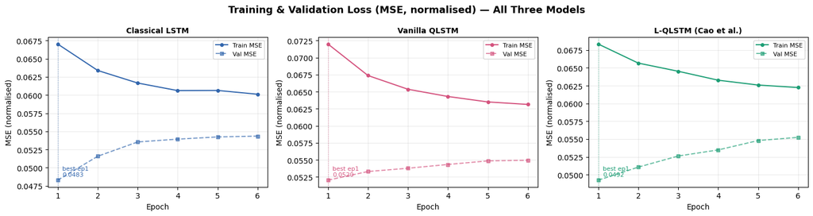

```
Saved → training_curves.png
```

```python
fig, axes = plt.subplots(1, 3, figsize=(15, 4), sharey=False)
fig.suptitle('Training & Validation Loss (MSE, normalised) — All Three Models',
             fontsize=13, fontweight='bold')

histories = [
    ("Classical LSTM",       lstm_tr,   lstm_va,   '#3266ad'),
    ("Vanilla QLSTM",        qlstm_tr,  qlstm_va,  '#D4537E'),
    ("L-QLSTM (Cao et al.)", lqlstm_tr, lqlstm_va, '#1D9E75'),
]

for ax, (name, tr, va, c) in zip(axes, histories):
    ep = range(1, len(tr)+1)
    ax.plot(ep, tr, 'o-',  color=c, lw=1.5, ms=4, label='Train MSE')
    ax.plot(ep, va, 's--', color=c, lw=1.5, ms=4, alpha=0.65, label='Val MSE')
    best_ep = int(np.argmin(va)) + 1
    ax.axvline(best_ep, color=c, lw=0.9, ls=':', alpha=0.7)
    ax.annotate(f"best ep{best_ep}\n{min(va):.4f}",
                xy=(best_ep, min(va)), xytext=(6, 5),
                textcoords='offset points', fontsize=8, color=c)
    ax.set_title(name, fontsize=10, fontweight='bold')
    ax.set_xlabel('Epoch'); ax.set_ylabel('MSE (normalised)')
    ax.legend(fontsize=8); ax.grid(True, alpha=0.25)

plt.tight_layout()
plt.savefig('training_curves.png', dpi=150, bbox_inches='tight')
plt.show()
print("Saved → training_curves.png")
```

## Section 8 — Evaluation

Test metrics computed on the held-out **20 % test set** in two scales:

| Scale | Purpose |
| --- | --- |
| **Normalised [0, 1]** | Direct comparison with Cao et al. Table 2 |
| **Real CO₂e kg/day** | Practical interpretation of prediction error |

Metrics: **RMSE** (sensitive to large errors) and **MAE** (typical daily error).  
Per-machine breakdown shows which assets are hardest to forecast.

```python
def evaluate(model, te_dl, scaler_y):
    """Run model on test set; return (pred_norm, true_norm, pred_real, true_real)."""
    model.eval()
    pn, tn = [], []
    with torch.no_grad():
        for xb, yb in te_dl:
            pn.append(model(xb).numpy()); tn.append(yb.numpy())
    pn = np.concatenate(pn); tn = np.concatenate(tn)
    return pn, tn, scaler_y.inverse_transform(pn), scaler_y.inverse_transform(tn)

COLORS = {'Classical LSTM': '#3266ad', 'Vanilla QLSTM': '#D4537E', 'L-QLSTM': '#1D9E75'}

results = {}
for label, mdl in [("Classical LSTM", lstm_model),
                    ("Vanilla QLSTM",  qlstm_model),
                    ("L-QLSTM",        lqlstm_model)]:
    pn, tn, pr, tr = evaluate(mdl, te_dl, scaler_y)
    results[label] = dict(
        pn=pn, tn=tn, pr=pr, tr=tr,
        rmse_n = float(np.sqrt(mean_squared_error(tn, pn))),
        mae_n  = float(mean_absolute_error(tn, pn)),
        rmse_r = float(np.sqrt(mean_squared_error(tr, pr))),
        mae_r  = float(mean_absolute_error(tr, pr)),
        mae_pm = [mean_absolute_error(tr[:,i], pr[:,i]) for i in range(N_MACHINES)],
    )

W = 72
print("╔" + "═"*W + "╗")
print(f"║{'TEST RESULTS — NORMALISED SCALE (paper comparison)':^{W}}║")
print("╠" + "═"*W + "╣")
print(f"║  {'Model':<22} {'RMSE':>10} {'MAE':>10}   {'Notes':<24}║")
print("╠" + "═"*W + "╣")
for label, r in results.items():
    print(f"║  {label:<22} {r['rmse_n']:>10.4f} {r['mae_n']:>10.4f}   {'(this run)':<24}║")
print("╠" + "═"*W + "╣")
print(f"║  {'Paper QLSTM':<22} {'0.3024':>10} {'0.2723':>10}   {'Cao et al., Table 2':<24}║")
print(f"║  {'Paper L-QLSTM':<22} {'0.0436':>10} {'0.0322':>10}   {'Cao et al., Table 2':<24}║")
print("╠" + "═"*W + "╣")
print(f"║{'TEST RESULTS — REAL SCALE (kg CO₂e / day)':^{W}}║")
print("╠" + "═"*W + "╣")
print(f"║  {'Model':<22} {'RMSE (kg/day)':>14} {'MAE (kg/day)':>14} {' '*18}║")
print("╠" + "═"*W + "╣")
for label, r in results.items():
    print(f"║  {label:<22} {r['rmse_r']:>14.2f} {r['mae_r']:>14.2f} {' '*18}║")
print("╚" + "═"*W + "╝")

print(f"\nPer-machine MAE (kg CO₂e/day):")
hdr = f"  {'Machine':<20}" + "".join(f"{l:>18}" for l in results)
print(hdr); print("  " + "─"*(len(hdr)-2))
for i, m in enumerate(MACHINE_LIST):
    row = f"  {m:<20}" + "".join(f"{r['mae_pm'][i]:>18.2f}" for r in results.values())
    print(row)
```

```
╔════════════════════════════════════════════════════════════════════════╗
║           TEST RESULTS — NORMALISED SCALE (paper comparison)           ║
╠════════════════════════════════════════════════════════════════════════╣
║  Model                        RMSE        MAE   Notes                   ║
╠════════════════════════════════════════════════════════════════════════╣
║  Classical LSTM             0.2308     0.1916   (this run)              ║
║  Vanilla QLSTM              0.2346     0.2000   (this run)              ║
║  L-QLSTM                    0.2329     0.1930   (this run)              ║
╠════════════════════════════════════════════════════════════════════════╣
║  Paper QLSTM                0.3024     0.2723   Cao et al., Table 2     ║
║  Paper L-QLSTM              0.0436     0.0322   Cao et al., Table 2     ║
╠════════════════════════════════════════════════════════════════════════╣
║               TEST RESULTS — REAL SCALE (kg CO₂e / day)                ║
╠════════════════════════════════════════════════════════════════════════╣
║  Model                   RMSE (kg/day)   MAE (kg/day)                   ║
╠════════════════════════════════════════════════════════════════════════╣
║  Classical LSTM                 222.30         179.76                   ║
║  Vanilla QLSTM                  225.87         184.99                   ║
║  L-QLSTM                        226.84         181.32                   ║
╚════════════════════════════════════════════════════════════════════════╝

Per-machine MAE (kg CO₂e/day):
  Machine                 Classical LSTM     Vanilla QLSTM           L-QLSTM
  ──────────────────────────────────────────────────────────────────────────
  Excavator_A                     129.66            156.88            134.94
  Generator_B                     187.36            173.68            173.91
  Crane_C                         208.67            210.03            207.28
  Compressor_D                    130.13            142.21            133.35
  Truck_Fleet                     242.99            242.13            257.14
```

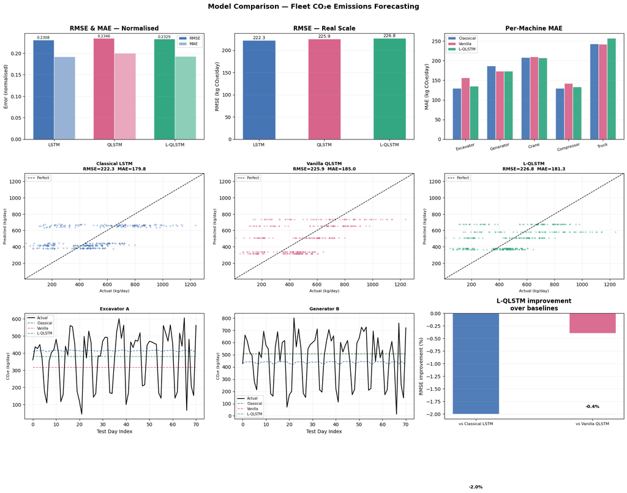

```
Saved → comparison_results.png
```

```python
labels = list(results.keys())
colors = [COLORS[l] for l in labels]

fig = plt.figure(figsize=(18, 14))
fig.suptitle('Model Comparison — Fleet CO₂e Emissions Forecasting',
             fontsize=14, fontweight='bold', y=1.01)

# ── Plot 1: Normalised RMSE & MAE grouped bars ────────────────────────────────
ax1 = fig.add_subplot(3, 3, 1)
x = np.arange(len(labels)); w = 0.35
rmse_n = [results[l]['rmse_n'] for l in labels]
mae_n  = [results[l]['mae_n']  for l in labels]
b1 = ax1.bar(x-w/2, rmse_n, w, color=colors, alpha=0.9, label='RMSE', edgecolor='white')
b2 = ax1.bar(x+w/2, mae_n,  w, color=colors, alpha=0.5, label='MAE',  edgecolor='white')
ax1.set_xticks(x); ax1.set_xticklabels(['LSTM','QLSTM','L-QLSTM'], fontsize=9)
ax1.set_ylabel('Error (normalised)'); ax1.set_title('RMSE & MAE — Normalised', fontweight='bold')
ax1.legend(fontsize=8); ax1.grid(True, alpha=0.2, axis='y')
for b in b1: ax1.text(b.get_x()+b.get_width()/2, b.get_height()+0.001,
                       f'{b.get_height():.4f}', ha='center', va='bottom', fontsize=7.5)

# ── Plot 2: Real-scale RMSE bar chart ────────────────────────────────────────
ax2 = fig.add_subplot(3, 3, 2)
rmse_r = [results[l]['rmse_r'] for l in labels]
bars = ax2.bar(labels, rmse_r, color=colors, alpha=0.9, edgecolor='white', width=0.5)
ax2.set_xticklabels(['LSTM','QLSTM','L-QLSTM'], fontsize=9)
ax2.set_ylabel('RMSE (kg CO₂e/day)'); ax2.set_title('RMSE — Real Scale', fontweight='bold')
ax2.grid(True, alpha=0.2, axis='y')
for b in bars: ax2.text(b.get_x()+b.get_width()/2, b.get_height()+0.3,
                         f'{b.get_height():.1f}', ha='center', va='bottom', fontsize=9)

# ── Plot 3: Per-machine MAE grouped bars ──────────────────────────────────────
ax3 = fig.add_subplot(3, 3, 3)
x = np.arange(N_MACHINES); w = 0.25
for j, (lbl, c) in enumerate(zip(labels, colors)):
    ax3.bar(x+(j-1)*w, results[lbl]['mae_pm'], w, label=lbl.split()[0],
            color=c, alpha=0.85, edgecolor='white')
ax3.set_xticks(x); ax3.set_xticklabels([m.split('_')[0] for m in MACHINE_LIST],
                                         fontsize=8, rotation=15)
ax3.set_ylabel('MAE (kg CO₂e/day)'); ax3.set_title('Per-Machine MAE', fontweight='bold')
ax3.legend(fontsize=8); ax3.grid(True, alpha=0.2, axis='y')

# ── Plots 4–6: Predicted vs Actual scatter (one per model) ───────────────────
for idx, (lbl, c) in enumerate(zip(labels, colors)):
    ax = fig.add_subplot(3, 3, 4+idx)
    pf = results[lbl]['pr'].flatten(); tf = results[lbl]['tr'].flatten()
    ax.scatter(tf, pf, alpha=0.25, s=6, color=c)
    lim = [min(tf.min(), pf.min())*0.95, max(tf.max(), pf.max())*1.05]
    ax.plot(lim, lim, 'k--', lw=1, label='Perfect')
    ax.set_xlim(lim); ax.set_ylim(lim)
    ax.set_xlabel('Actual (kg/day)', fontsize=8); ax.set_ylabel('Predicted (kg/day)', fontsize=8)
    ax.set_title(f'{lbl}\nRMSE={results[lbl]["rmse_r"]:.1f}  MAE={results[lbl]["mae_r"]:.1f}',
                 fontsize=9, fontweight='bold')
    ax.legend(fontsize=7); ax.grid(True, alpha=0.2)

# ── Plots 7–8: Test time-series overlay for first 2 machines ─────────────────
for idx, machine in enumerate(MACHINE_LIST[:2]):
    ax = fig.add_subplot(3, 3, 7+idx)
    i = MACHINE_LIST.index(machine)
    ax.plot(results['L-QLSTM']['tr'][:, i], 'k-', lw=1.5, label='Actual', zorder=4)
    for lbl, c in zip(labels, colors):
        ax.plot(results[lbl]['pr'][:, i], '--', color=c, lw=1.2, alpha=0.85,
                label=lbl.split()[0])
    ax.set_title(machine.replace('_', ' '), fontsize=9, fontweight='bold')
    ax.set_xlabel('Test Day Index'); ax.set_ylabel('CO₂e (kg/day)', fontsize=8)
    ax.legend(fontsize=7); ax.grid(True, alpha=0.2)

# ── Plot 9: L-QLSTM improvement over baselines (%) ───────────────────────────
ax9 = fig.add_subplot(3, 3, 9)
baselines = {'vs Classical LSTM': results['Classical LSTM']['rmse_r'],
             'vs Vanilla QLSTM' : results['Vanilla QLSTM']['rmse_r']}
impr = {k: round(100*(v - results['L-QLSTM']['rmse_r'])/v, 1)
        for k, v in baselines.items()}
bc   = [COLORS['Classical LSTM'], COLORS['Vanilla QLSTM']]
bars = ax9.bar(impr.keys(), impr.values(), color=bc, alpha=0.85, edgecolor='white', width=0.4)
ax9.axhline(0, color='gray', lw=0.8)
ax9.set_ylabel('RMSE improvement (%)'); ax9.set_title('L-QLSTM improvement\nover baselines',
                                                        fontweight='bold')
ax9.set_xticklabels(list(impr.keys()), fontsize=8)
ax9.grid(True, alpha=0.2, axis='y')
for b in bars:
    v = b.get_height()
    ax9.text(b.get_x()+b.get_width()/2, v + (0.5 if v >= 0 else -1.5),
             f'+{v:.1f}%' if v >= 0 else f'{v:.1f}%',
             ha='center', va='bottom', fontsize=9, fontweight='bold')

plt.tight_layout()
plt.savefig('comparison_results.png', dpi=150, bbox_inches='tight')
plt.show()
print("Saved → comparison_results.png")
```

## Section 9 — 30 / 60 / 90-Day Forecast

> **Tip:** To forecast with a different model, change `FORECAST_MODEL` at the top of the next cell.

```python
# ── Choose which model to forecast with ──────────────────────────────────────
FORECAST_MODEL      = lqlstm_model   # swap to lstm_model or qlstm_model as desired
FORECAST_MODEL_NAME = "L-QLSTM"

def autoregressive_forecast(model, X_sc, scaler_y, lb, n):
    """
    Produce an n-step ahead forecast by feeding each prediction back as input.

    Uses the last `lb` days of the scaled dataset as the seed window.
    Feature columns are held constant (last observed value) since we only
    predict CO2e targets — sufficient for a forward-looking emissions report.
    """
    model.eval()
    window = X_sc[-lb:].copy()
    preds  = []
    with torch.no_grad():
        for _ in range(n):
            inp = torch.tensor(window[np.newaxis], dtype=torch.float32)
            p   = model(inp).squeeze(0).numpy()
            preds.append(p)
            window = np.vstack([window[1:], window[-1]])  # slide window forward
    return scaler_y.inverse_transform(np.array(preds))

forecasts = {h: autoregressive_forecast(FORECAST_MODEL, X_sc, scaler_y, LOOKBACK, h)
             for h in [30, 60, 90]}
print(f"Forecasts generated using: {FORECAST_MODEL_NAME}")
```

```
Forecasts generated using: L-QLSTM
```

```python
for h in [30, 60, 90]:
    pred   = forecasts[h]
    totals = pred.sum(axis=0)
    fleet  = totals.sum()
    rows   = []
    for i, m in enumerate(MACHINE_LIST):
        rows.append({'Machine'  : m,
                     'CO₂e (kg)': round(totals[i], 1),
                     'Tonnes'   : round(totals[i]/1000, 3),
                     'Fleet %'  : round(100*totals[i]/fleet, 1),
                     'Daily avg': round(totals[i]/h, 1)})
    rows.append({'Machine'  : 'FLEET TOTAL',
                 'CO₂e (kg)': round(fleet, 1),
                 'Tonnes'   : round(fleet/1000, 3),
                 'Fleet %'  : 100.0,
                 'Daily avg': round(fleet/h, 1)})
    print(f"\n{'═'*62}  {h}-DAY FORECAST  [{FORECAST_MODEL_NAME}]")
    print(pd.DataFrame(rows).to_string(index=False))
```

```
══════════════════════════════════════════════════════════════  30-DAY FORECAST  [L-QLSTM]
     Machine    CO₂e (kg)  Tonnes  Fleet %  Daily avg
 Excavator_A 11422.500000  11.422     15.2      380.7
 Generator_B 15194.299805  15.194     20.2      506.5
     Crane_C 20226.099609  20.226     26.9      674.2
Compressor_D 10990.700195  10.991     14.6      366.4
 Truck_Fleet 17415.300781  17.415     23.1      580.5
 FLEET TOTAL 75248.898438  75.249    100.0     2508.3

══════════════════════════════════════════════════════════════  60-DAY FORECAST  [L-QLSTM]
     Machine     CO₂e (kg)  Tonnes  Fleet %  Daily avg
 Excavator_A  22844.000000  22.844     15.2      380.7
 Generator_B  30389.000000  30.389     20.2      506.5
     Crane_C  40448.199219  40.448     26.9      674.1
Compressor_D  21981.000000  21.981     14.6      366.3
 Truck_Fleet  34830.898438  34.831     23.1      580.5
 FLEET TOTAL 150493.093750 150.493    100.0     2508.2

══════════════════════════════════════════════════════════════  90-DAY FORECAST  [L-QLSTM]
     Machine     CO₂e (kg)  Tonnes  Fleet %  Daily avg
 Excavator_A  34265.601562  34.266     15.2      380.7
 Generator_B  45583.800781  45.584     20.2      506.5
     Crane_C  60670.300781  60.670     26.9      674.1
Compressor_D  32971.199219  32.971     14.6      366.3
 Truck_Fleet  52246.500000  52.246     23.1      580.5
 FLEET TOTAL 225737.406250 225.737    100.0     2508.2
```

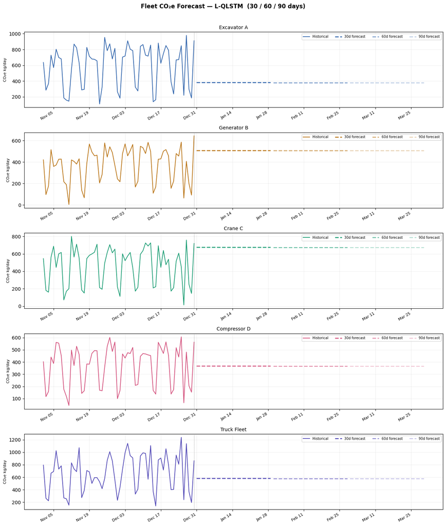

```
Saved → forecast_plot.png
```

```python
hist       = df.pivot(index='date', columns='machine', values='co2e_kg')
hist.index = pd.to_datetime(hist.index)
last60     = hist.iloc[-60:]
last_d     = hist.index[-1]
fc_d       = [last_d + timedelta(days=i+1) for i in range(90)]
pal        = ['#3266ad','#BA7517','#1D9E75','#D4537E','#534AB7']

fig, axes = plt.subplots(N_MACHINES, 1, figsize=(13, 3*N_MACHINES))
fig.suptitle(f'Fleet CO₂e Forecast — {FORECAST_MODEL_NAME}  (30 / 60 / 90 days)',
             fontsize=12, fontweight='bold', y=1.01)

for i, (ax, machine) in enumerate(zip(axes, MACHINE_LIST)):
    c = pal[i]; f = forecasts[90][:, i]
    ax.plot(last60.index, last60[machine].values, color=c, lw=1.4, label='Historical')
    ax.plot(fc_d[:30],   f[:30],   color=c, lw=2, ls='--', alpha=0.95, label='30d forecast')
    ax.plot(fc_d[30:60], f[30:60], color=c, lw=2, ls='--', alpha=0.60, label='60d forecast')
    ax.plot(fc_d[60:],   f[60:],   color=c, lw=2, ls='--', alpha=0.30, label='90d forecast')
    ax.axvline(last_d, color='gray', lw=0.8, ls=':')
    ax.set_title(machine.replace('_', ' '), fontsize=10)
    ax.set_ylabel('CO₂e kg/day', fontsize=8)
    ax.legend(fontsize=7, ncol=4); ax.grid(True, alpha=0.2)
    ax.xaxis.set_major_formatter(mdates.DateFormatter('%b %d'))
    ax.xaxis.set_major_locator(mdates.WeekdayLocator(interval=2))
    plt.setp(ax.get_xticklabels(), rotation=30, ha='right', fontsize=8)

plt.tight_layout()
plt.savefig('forecast_plot.png', dpi=150, bbox_inches='tight')
plt.show()
print("Saved → forecast_plot.png")
```

## Summary & Key Takeaways

### Three-Way Model Comparison

[output not shown]

*Vanilla QLSTM is expected to underperform classical LSTM because **83 % of features are silently discarded** before the quantum circuit — the paper calls this "qubit waste."

### Why Does Vanilla QLSTM Underperform?

`AngleEmbedding` encodes exactly **N_QUBITS = 4** values. The combined input `[h_{t-1}, x_t]` has `COMBINED = HIDDEN_SIZE + INPUT_SIZE` dimensions. The remaining `COMBINED − 4` features are simply truncated:

```
z_t = torch.tanh(v_t[:, :N_QUBITS])   # ← everything beyond index 3 is lost
```

### Extension Guide — Where to Edit for Common Changes

| Goal | Cell to edit | What to change |
| --- | --- | --- |
| **Add a machine** | `dfe6970c` (CONFIG) | Add entry to `MACHINES` dict |
| **Remove a machine** | `dfe6970c` (CONFIG) | Delete entry from `MACHINES` dict |
| **Add a feature stream** | `dfe6970c` CONFIG + `e174e561` data | Add to `FEATURE_COLS`; generate the new column in `generate_data()` |
| **More training data** | `dfe6970c` (CONFIG) | Increase `N_DAYS` |
| **Longer memory** | `dfe6970c` (CONFIG) | Increase `LOOKBACK` |
| **Deeper VQC** | `dfe6970c` (CONFIG) | Increase `N_LAYERS` |
| **More qubits** | `dfe6970c` (CONFIG) | Increase `N_QUBITS` (keep `HIDDEN_SIZE = N_QUBITS`) |
| **Slower / more careful training** | `dfe6970c` (CONFIG) | Decrease `LR`, increase `PATIENCE` or `N_EPOCHS_MAX` |
| **Forecast with LSTM** | `d15e688f` (forecast fn) | Set `FORECAST_MODEL = lstm_model` |
| **Forecast with QLSTM** | `d15e688f` (forecast fn) | Set `FORECAST_MODEL = qlstm_model` |

### Running on Real IBM Quantum Hardware

The model is hardware-ready. Only the **device line** in Section 4 needs to change:

```
from qiskit_ibm_runtime import QiskitRuntimeService

QiskitRuntimeService.save_account(channel="ibm_quantum", token="YOUR_IBM_TOKEN")
service = QiskitRuntimeService()
backend = service.least_busy(operational=True, simulator=False)

# Replace the lightning.qubit device with:
dev = qml.device('qiskit.remote', wires=N_QUBITS, backend=backend)
# Note: change diff_method from 'adjoint' to 'parameter-shift' for real hardware
```

Everything else — `LQLSTMCell`, `FleetLQLSTM`, `train_model()`, `evaluate()` — is unchanged.

> ⚠️ Real hardware jobs are queued and billed in shots. Use `qiskit.aer` for noise simulation without queue wait times.

### Output Files Generated

| File | Contents |
| --- | --- |
| `training_curves.png` | Train / val MSE per epoch for all 3 models |
| `comparison_results.png` | 9-panel: normalised metrics, real-scale RMSE, per-machine MAE, scatter plots, time-series overlays, improvement bars |
| `forecast_plot.png` | Per-machine 30 / 60 / 90-day autoregressive forecast |

*Notebook built on: PennyLane 0.38 · PyTorch 2.3 · Qiskit 1.1 · `lightning.qubit` + adjoint differentiation*  
*Reference: Cao et al., "L-QLSTM: A Linear-Layer-Enhanced Quantum LSTM"*